# N-BEATS neural network for mid-term electricity load forecasting

- mid-term 전력 예측 문제
- 출처 논문 : N-BEATS neural network for mid-term electricity load forecasting Boris N. Oreshkin a,∗, Grzegorz Dudek b, Paweł Pełka b, Ekaterina Turkina c
- https://arxiv.org/pdf/2009.11961.pdf

## 1. Introduction

- 전력소비와 생산의 밸런스를 유지한는 것은 power systemdm의 안전과 효율을 위한 중요한 조건이다
- 수요와 예측을 정확히 예측하는 것은 위의 조건을 충족하는 중요한 포인트임
- 예를 들어 캘리포니아에서 태양열의 에너지 예측을 통해 여러 비용을 효과적으로 줄일 수 있었다고 함

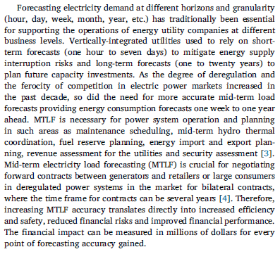

- Forecasting electricity는 각각의 horizons과 계절성분의 세밀함을 전통적으로 필수적이었음
- Vertically-integrated utilities 는 에너지 공급 중단 위험에 의존하는 단기적 예측과 향후 수용 능력에 대한 예측은 장기적 예측을 이용해왔다
- 지난 10년간 규제 완화 정도와 전력시장에서 경쟁은 증가함
- 따라서 중기(one week~ one year) 에너지 생산의 예측과 소비 예측은 필요해졌다
- 정리 : MTLF정확성을 증가는 효율성과 안정성의 증가이고 재정적 위험을 줄이고 경제적 이득을 증가시킨다.

## 1.2. Motivation and contributions

```
    In this paper, our main focus is mid-term electricity load forecasting
    with monthly granularity over a 12-month horizon. Existing work in
    the area of MTLF has a number of significant limitations and gaps,
    which we address and bridge in our current work
```

- 12개월의 기간에 대한 중기 전력 예측에 집중, MTLF의 이러한 연구는 많은 제약과 갭을 가지고 있지만 본인들의 연구가 보완점이 되어줄 것

```
First, many of the existing works focus on linear or simple non-linear regression models that have limited modeling power [3]. In this research, we clearly demonstrate that advanced non-linear modeling relying on N-BEATS deep neural network architecture leads to substantial improvement inMTLF accuracy compared to such well-established models as ARIMA and ETS.
```

- 많은 연구들은 선형 또는 단순한 비선형 회귀 모델을 집중하고 있지만 이 연구에서 명백히 우리는 MTLF의 정확성이 기존 ARIMA나 ETS와 비교할 때 딥러닝 모델인 n-beats을 이용한 진보된 비선형 모델이 성능이 좋다는 것을 입증할 것

```
Second, existing work exploring advanced forecasting techniques in MTLF has provided limited statistical analyses of forecasting errors, largely ignoring the analysis of the significance of forecasting accuracy gain (see for example the applications of machine learning [12], bagging of classical models [26], NNs [11], NNs in combination with kernel PCA [27] and soft computing [28])
```

- MTLF에서 고급 예측 기술을 탐색하는 기존 작업은 예측 정확도 이득의 중요성에 대한 분석을 대부분 무시하고 예측 오류에 대한 제한된 통계 분석을 제공
- NNs [11], NNs in combination with kernel PCA [27] and soft computing

```
In this paper, we clearly demonstrate that N-BEATS has a statistically significant forecasting accuracy gain with respect to statistical models as well as state-of-theart machine learning and hybrid models
```

- N-BEATS가 통계 모델뿐만 아니라 최첨단 기계 학습 및 하이브리드 모델과 관련하여 통계적으로 유의한 예측 정확도 이득을 가지고 있음을 명확하게 입증

```
    Third, the original work on N-BEATS demonstrated its effectiveness on challenging competition datasets containing tens of thousands of time series from diverse domains [25].However, MTLF datasets tend to be rather small (dozens or hundreds of time series at best). This can be an obstacle for effectively applying powerful deep neural networks such as N-BEATS in the small-data regime.
```

- n-beats는 많은 양의 시계열과 다양한 도메인에서 효과적인 경쟁을 했다는 것 보여줌
- 하지만 MTLF는 데이터셋의 크기가 작은 경향이 있음
- 소규모 데이터셋은 딥러닝 모형에 적절하지가 않음

```
First, small dataset size exacerbates overfitting problems: large networks trained on few samples may have small error on the training set, but will fail to generalize on the unseen data in the test set. Second, hyperparameter values selected on a small validation set may be noisy and may fail to generalize on the test set. Finally, a common way to combat overfit is to reduce network capacity (e.g., reduce the width and the number of layers). There is significant uncertainty then whether the reduced-capacity network will be able to deliver the improved non-linear modeling capabilities to outperform classical statistical models on a small dataset.
```

1. 작은 데이터셋은 과적합 문제를 일으킨다.
2. 작은 검정셋에서 선택된 하이퍼파라미터가 테스트셋의 일반적으로 적용되는 것이 실패할 수 있고 잡음이 많을 수 있다
3. 이러한 과적합을 방지하는 흔한 방법은 네트워크의 용량을 줄이는 것이다. 하지만 용량을 줄이게 된다는 것은 고전 통계 모델과 비교해볼 때 이들의 수행 향상이 잘 된다는 것에 불확실성이 있다

```
In this work, we clearly demonstrate that N-BEATS can effectively be applied to small-scale forecasting problems such as MTLF and result in stateof- the-art performance. Finally, existing forecasting algorithms focus only on improving forecasting accuracy and ignore the bias of the forecasts, which plays a crucial role in MTLF. Therefore, existing algorithms exhibit biased forecasts with uncontrollable forecasting bias when applied to the MTLF problem [18]. In this paper, we propose a simple and effective mechanism to control for forecasting bias using the pinball-mape loss function and demonstrate its effectiveness on real data
```

- 이 연구에서는 N-BEATS가 MTLF와 같은 소규모 예측 문제에 효과적으로 적용되어 최첨단 성능을 발휘할 수 있음을 명확하게 보여줌
- 마지막으로 기존 예측 알고리즘은 예측 정확도 향상에만 초점을 맞추고 MTLF에 중요한 역할을 하는 예측의 편향성을 무시한다 따라서 기존 알고리즘은 MTLF 문제에 적용할 때 제어할 수 없는 예측 편향성을 보인다.
- 이 논문에서는 핀볼 맵 손실 함수를 사용하여 예측 편향을 제어하는 간단하고 효과적인 메커니즘을 제안하고 실제 데이터에 대한 효과를 입증함

`-` Our research contributions can be summarized as follows:

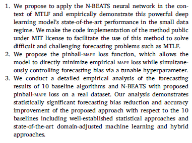

1. 소규모데이터셋을 적합하는데 뉴럴 네트워크를 이용
2. 핀볼 MAPE 로스펑션을 제안
3. 10개의 다른 베이스라인 모델과 비교했을 때 nbeats 모델의 예측 성능을 보여준다

## N-BEATS for MTLF

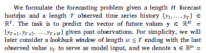

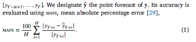

- 예측할 H horizen과 관찰된 시계열의 history에서 length T가 주어지면 예측문제를 formulate함
- 이 task는 주어진 과거의 관찰된 것으로부터 미래의 y value의 vector를 예측하는 것
- 단순하게 우리는 lookback wondow의 길이는 모델에서 $w \le T$로 고려할 것

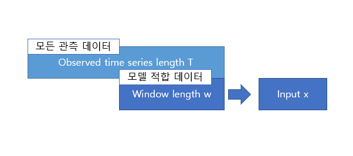

## 2.2. Lookback window selection

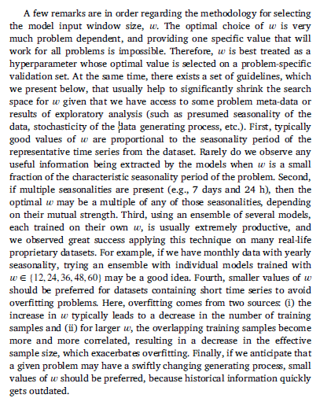

- The optimal choice of 𝑤 is very much problem dependent, and providing one specific value that will work for all problems is impossible
- 따라서 𝑤는 문제별 검증 세트에서 선택된 최적값으로 취급하는 것이 가장 좋음
- 동시에, 어떤 문제의 메타 데이터나 탐색적 분석 결과(데이터의 추정된 계절성, 데이터 생성 과정의 확률성 등)에 액세스할 수 있는 경우, 보통 검색 공간을 크게 줄여주는 일련의 지침이 있다
  1. 첫째, 일반적으로 𝑤의 좋은 값은 데이터셋의 대표적인 시계열의 계절성 주기에 비례함. 문제의 특성 계절성 주기의 작은 분수일 때 모델이 유용한 정보를 추출하는 것을 거의 관찰하지 못한다.
  2. 둘째, 여러 계절성이 존재하는 경우(예: 7일 및 24시간), 최적의 𝑤는 그러한 계절성 중 어느 것이든 그 배수일 수 있으며, 상호 강도에 따라 달라진다.
  3. 셋째, 여러 모델 앙상블을 사용하는 것이 보통 매우 생산적이며, 우리는 이 기술을 많은 실제 소유 데이터셋에 적용하여 큰 성공을 경험하였다. 예를 들어, 연간 계절성이 있는 월간 데이터가 있는 경우, 𝑤 ∈ {12, 24, 36, 48, 60}로 훈련된 개별 모델을 사용한 앙상블을 시도하는 것이 좋은 아이디어!
  4. 넷째, 과적합 문제를 피하기 위해 짧은 시계열을 포함하는 데이터셋에 대해서는 작은 𝑤 값을 선호해야 함
- 과적합은 두 가지 원인으로부터 발생
  - 𝑤의 증가는 일반적으로 훈련 샘플의 수를 감소
  - 𝑤가 클수록, 겹치는 훈련 샘플이 더욱 상관 관계가 있어서 효과적인 샘플 크기가 감소하며, 이는 과적합을 악화
  - 마지막으로, 특정 문제의 생성 프로세스가 빠르게 변할 수 있다고 예상되는 경우, 과거 정보가 빠르게 오래되므로 작은 𝑤 값을 선호해야 함

## 2.3. N-BEATS architecture

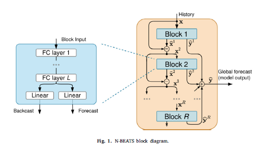

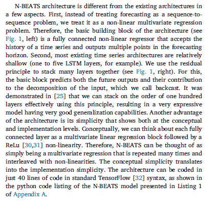

- N-BEATS 아키텍처는 기존 아키텍처와 몇 가지 측면에서 다르다.
- 첫째, 예측을 시퀀스 대 시퀀스 문제로 처리하는 대신, 비선형 다변량 회귀 문제로 처리. 따라서 아키텍처의 기본 빌딩 블록은 시계열을 받아들이고 예측 기간 내에서 여러 지점을 출력하는 완전 연결 비선형 회귀문제임.
- 둘째, 대부분의 기존 시계열 아키텍처는 비교적 얕다(예: 하나에서 다섯 개의 LSTM 레이어). 우리는 많은 레이어를 쌓기 위해 잔차 원리를 사용 이를 위해 기본 블록은 미래 출력과 그들의 기여를 예측하는 것 두 가지를 동시에 예측한다. 이것을 우리는 backcast라고 부르고. 이 원리를 사용하여 수백 개의 레이어를 효과적으로 쌓을 수 있다는 것이 [25]에서 입증되었으며, 이는 매우 표현력이 뛰어나며 매우 우수한 일반화 능력을 가진 모델을 얻게 됨.
- 이 아키텍처의 또 다른 장점은 개념 및 구현 수준에서의 간결함이다. 개념적으로, 우리는 각 완전 연결 레이어를 ReLU 비선형성이 뒤따르는 다변량 선형 회귀 블록으로 생각할 수 있습니다. 따라서 N-BEATS는 단순히 여러 번 반복되고 비선형성과 교차로 배치된 다변량 회귀로 생각할 수 있다. 개념적인 간결함은 구현 간결함으로 이어진다.

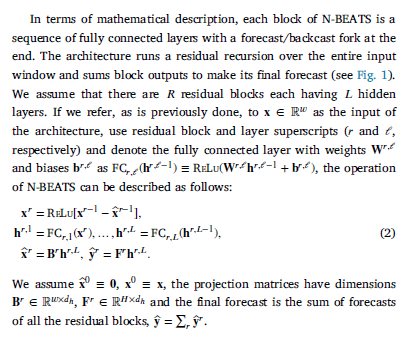

## 2.4. Pinball-mape loss function

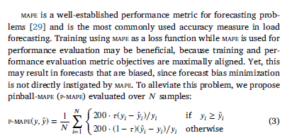

- The 𝜏 parameter in the p-mape loss function can be adjusted on the validation set to compensate for biases arising from the training on mape loss.
- Note that the use of lower 𝜏 values to avoid over-forecasting with mae based training was proposed by Smyl
- p-mape loss with 𝜏 = 0.5 is equivalent to mape loss. Setting 𝜏 ∈ (0, 0.5) will tend to compensate for over-estimation bias, and setting 𝜏 ∈ (0.5, 1) will tend to compensate for under-estimation bias. We conjecture that a similar approach may be used with other loss functions

## 3. Experimental results

## 3.1. Dataset

- 모델은 유럽 35개국의 월간 전기 수요로 구성된 실제 데이터를 www.entsoe.eu에서 수집한 데이터에 적용되었다.
- 데이터셋의 전기 수요 시계열은 비선형 추세, 계절성 및 무작위 구성 요소를 나타냄.
- 추세는 각 나라의 경제 성장률 및 기후 변화(예: 온실 가스 배출에 의한 지구 온난화 및 기타 요인)에 따라 달라지며, 계절성은 지역 기후 및 날씨 변동성과 고객 구조와 관련이 있음.
- 전기 수요 시계열을 방해하는 요인으로는 예측할 수 없는 경제적 사건, 극단적인 날씨 조건 및 정치적 결정이 포함.

## 3.2. Training and evaluation setup

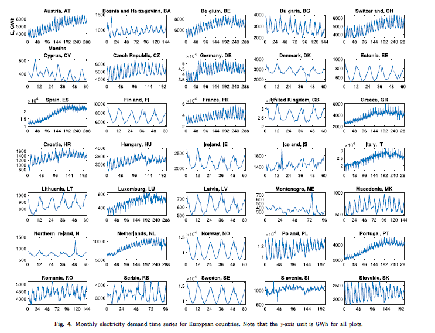

`-` lookback period w = 12

[figure not shown]

```
The dataset is split into train, validation and test subsets. The test subset is constructed by cutting the last horizon (twelve months of 2014) off each of the 35 time series. The validation and train subsets are obtained by splitting the full train sets at the boundary of the last horizon of each time series. Thus, we treat the twelve months of 2013 as a validation subset. We use the train and validation subsets to tune hyperparameters. Once the hyperparameters are determined, we train the model on the full train set and report results on the test set.
```

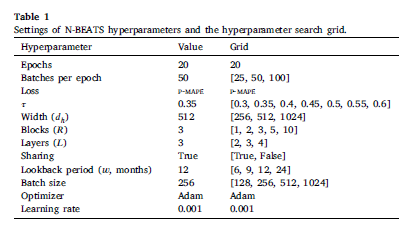

- 모든 하이퍼파라미터는 검증 세트에서 MAPE를 최소화하여 조정되었으며, 예외로 p-mape 손실 매개변수 𝜏은 예측 편향을 최소화하기 위해 검증 세트에서 선택되었다.
- 가중치 감쇠를 사용하지 않으며, 대신 64개 모델의 앙상블을 통해 정규화가 이루어짐. 앙상블의 각 모델은 다른 무작위 초기화 및 다른 무작위 배치 시퀀스를 사용하여 훈련
- 네트워크를 훈련하는 데 사용된 목적 함수는 섹션 2.4에서 설명된 pinball mape이며, 𝜏 = 0.35로 설정되었다 (배치 내의 모든 예측에 대해 평균화됨; 𝐻 = 12).

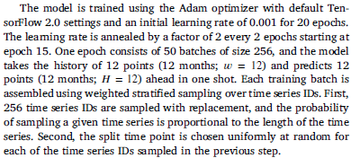

- 모델은 기본 TensorFlow 2.0 설정과 20개의 에포크에 대한 초기 학습률 0.001인 Adam optimizer를 사용하여 훈련.
- 학습률은 에포크 15에서 시작하여 2개의 에포크마다 2배씩 annealed됨. 하나의 에포크는 256 크기의 50개 배치로 구성되며 모델은 12개 지점(12개월; 𝑤 = 12)의 이력을 가져 한 번에 12개 지점(12개월; 𝐻 = 12)을 예측.
- 각 훈련 배치는 시계열 ID에 대한 가중 계층화 샘플링을 사용하여 조립된다.
  - 첫째, 256개의 시계열 ID를 대체하여 샘플링하고, 주어진 시계열을 샘플링할 확률은 시계열의 길이에 비례.
  - 둘째, 이전 단계에서 샘플링된 각 시계열 ID에 대해 분할 시점을 무작위로 균일하게 선택.

```
The weighted stratified sampling of time series is important because each time series has a different length. A training sample is formed by splitting a given time series at a split point, feeding the history window preceding the split point into the network and computing a loss using the values following the split point. Obviously, a smaller time series will generate a smaller number of unique training samples.
Therefore, we should not sample time series IDs uniformly. If we do, then each sample from a short time series will be used to adjust the training loss more times on average and the model will be overfitting more on the shorter time series than on the longer ones. Weighted stratified sampling solves this problem by making sure that each training sample is used to adjust  training loss the same number of times on average
```

- 시계열의 가중 계층화 샘플링은 각 시계열의 길이가 다르기 때문에 중요하다. 훈련 샘플은 주어진 시계열을 분할 지점에서 분할하고 분할 지점 이전의 이력 창을 네트워크로 공급하고 분할 지점 이후의 값을 사용하여 손실을 계산함으로써 형성. 분명히 작은 시계열은 더 적은 수의 고유한 훈련 샘플을 생성할 것이다.
- 따라서 우리는 시계열 ID를 일률적으로 샘플링해서는 안 된다. 그렇게 하면 짧은 시계열의 각 표본을 사용하여 훈련 손실을 평균적으로 더 많이 조정하고 모형이 긴 시계열보다 짧은 시계열에서 더 많이 과적합됨. 가중 계층화 샘플링은 각 훈련 표본을 사용하여 훈련 손실을 평균적으로 같은 횟수로 조정함으로써 이 문제를 해결

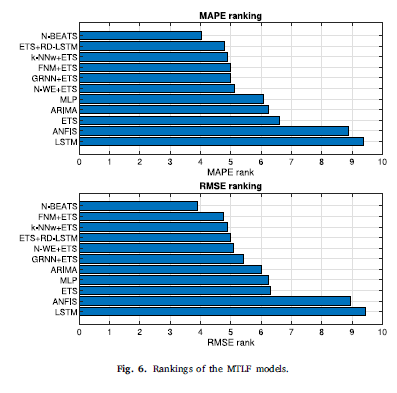

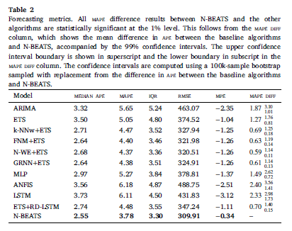

## 4. Conclusions

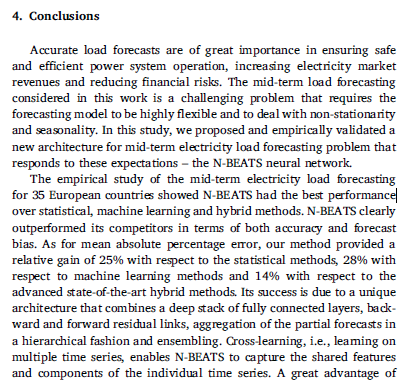

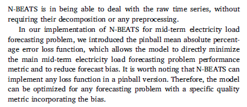

- 정확한 부하 예측은 안전하고 효율적인 전력 시스템 운영을 보장하고 전력 시장 수익을 증가시키고 재무 리스크를 줄이는 데 매우 중요
- 이 연구에서 고려된 중기 부하 예측은 예측 모델이 높은 유연성을 가져야 하고 비정상성 및 계절성을 처리해야 하는 어려운 문제
- 본 연구에서는 이러한 기대에 부응하는 중기 전력 부하 예측 문제에 대한 새로운 아키텍처인 N-BEATS 신경망을 제안하고 경험적으로 검증.
- 유럽 35개국의 중기 전력 부하 예측에 대한 경험적 연구 결과, N-BEATS가 통계, 기계 학습 및 혼합 방법에 비해 최고의 성능을 보여주었다.
- N-BEATS는 정확도와 예측 편향 측면에서 경쟁 모델을 뛰어넘었습니다. 평균 절대 백분율 오차에 대해 말하자면, 우리 방법은 통계 방법 대비 상대적인 이득으로 25%를 제공하였으며, 기계 학습 방법에 대해서는 28%를 제공하였으며, 고급 혼합 방법에 대해서는 14%를 제공했다.
- 이 성공은 완전히 연결된 레이어의 깊은 스택, 역방향 및 순방향 잔차 링크, 계층적으로 부분 예측을 집계하는 고유한 아키텍처 및 앙상블을 결합한 독특한 아키텍처 덕분이다. 다중 시계열에서 학습하는 교차 학습은 N-BEATS가 개별 시계열의 공통 특징과 구성 요소를 포착할 수 있도록 한다.
- 중기 전력 부하 예측 문제에서 N-BEATS의 큰 장점 중 하나는 전처리나 분해 없이 원시 시계열을 다룰 수 있다는 것!
- 저희가 중기 전력 부하 예측 문제에 대한 N-BEATS의 구현에서 소개한 핀볼 평균 절대 백분율 오차 손실 함수는 모델이 주요 중기 전력 부하 예측 문제 성능 측정 항목을 직접 최소화하고 예측 편향을 줄일 수 있게 함
- N-BEATS는 핀볼 버전의 모든 손실 함수를 구현할 수 있다는 점을 강조할 가치가 있다 따라서 모델은 어떤 손실 함수에도 최적화될 수 있음